# Recidivism_dataexploration

Group12

5/2/2020

```r
#Suppressing warnings about libraries
#Import  libraries (currently overdoing it)
library(tidyverse)
```

```r
library(ggplot2)      # graphics library
library(gridExtra)    # For displaying graphs side-by-side
library(knitr)        # contains knitting control
library(tree)         # For the tree-fitting 'tree' function
library(randomForest) # For random forests
library(rpart)        # For nicer tree fitting
library(partykit)     # For nicer tree plotting
library(boot)         # For cv.glm
library(leaps)        # needed for regsubsets (though maybe not relevant b/c our outcome vars are binary)
#Format numbers so that they are not in scientific notation.
options(scipen = 4)

###################################
# Read in all ProPublica datasets #
###################################
compas.scores.raw <- read_csv("C:\\Users\\uukay\\OneDrive\\Documents\\mini4\\Data Mining\\Final project\\RecidivismPrediction\\datasets\\compas-scores-raw.csv")

compas.scores <- read_csv("C:\\Users\\uukay\\OneDrive\\Documents\\mini4\\Data Mining\\Final project\\RecidivismPrediction\\datasets\\compas-scores.csv")
compas.scores.two.years <- read_csv("C:\\Users\\uukay\\OneDrive\\Documents\\mini4\\Data Mining\\Final project\\RecidivismPrediction\\datasets\\compas-scores-two-years.csv")
compas.scores.two.years.violent <- read_csv("C:\\Users\\uukay\\OneDrive\\Documents\\mini4\\Data Mining\\Final project\\RecidivismPrediction\\datasets\\compas-scores-two-years-violent.csv")
cox.parsed <- read_csv("C:\\Users\\uukay\\OneDrive\\Documents\\mini4\\Data Mining\\Final project\\RecidivismPrediction\\datasets\\cox-parsed.csv")
cox.violent.parsed <- read_csv("C:\\Users\\uukay\\OneDrive\\Documents\\mini4\\Data Mining\\Final project\\RecidivismPrediction\\datasets\\cox-violent-parsed.csv")
#Next step 1 (low LOE): Somebody fix so the file paths aren't just for my local directories. Here are three options in order of how ideal they would be:
#   The propublica github files
#   My forked version of the propublica github files:  https://github.com/kaylareiman1/compas-analysis
#   Our copied and pasted version of the propublica github files: https://github.com/kaylareiman1/RecidivismPrediction/tree/master/datasets

####################################
# Adapt ProPublica's Data Cleaning #
####################################
#Note: This code is copied directly from ProPublica. Here is why they dropped data:
      # - dropped if charge date not w/in 30 days
      # - Coded the recidivist flag -- is_recid -- to be -1 if could not find a compas case at all.
      # - Ordinary traffic offenses removed
      # - Filtered the underlying data from Broward county to include:
      #   + people who had either recidivated in two years
      #   + had at least two years outside of a correctional facility.

#Unlike ProPublica, we won't be dropping any attributes because that may bias our model.
### All recidivism ###

#Dropping bad data
nrow(compas.scores.two.years)
```

```
## [1] 7214
```

```r
recid.all <-compas.scores.two.years %>%
        filter(days_b_screening_arrest <= 30) %>%
        filter(days_b_screening_arrest >= -30) %>%
        filter(is_recid != -1) %>%
        filter(c_charge_degree != "O") %>%
        filter(score_text != 'N/A')
nrow(recid.all)
```

```
## [1] 6172
```

```r
#Recoding variables
recid.all$length_of_stay <- as.numeric(as.Date(recid.all$c_jail_out) - as.Date(recid.all$c_jail_in))
recid.all <- mutate(recid.all, crime_factor = factor(c_charge_degree)) %>%
      mutate(age_factor = as.factor(age_cat)) %>%
      within(age_factor <- relevel(age_factor, ref = 1)) %>%
      mutate(race_factor = factor(race)) %>%
      within(race_factor <- relevel(race_factor, ref = 3)) %>%
      mutate(gender_factor = factor(sex, labels= c("Female","Male"))) %>%
      within(gender_factor <- relevel(gender_factor, ref = 2)) %>%
      mutate(score_factor = factor(score_text != "Low", labels = c("LowScore","HighScore")))


### Violent recidivism ###
#Dropping bad data
nrow(compas.scores.two.years.violent)
```

```
## [1] 4743
```

```r
recid.vio <- compas.scores.two.years.violent %>%
        filter(days_b_screening_arrest <= 30) %>%
        filter(days_b_screening_arrest >= -30) %>%
        filter(is_recid != -1) %>%
        filter(c_charge_degree != "O") %>%
        filter(v_score_text != 'N/A')
nrow(recid.vio)
```

```
## [1] 4020
```

```r
#Recoding variables
#KR note: Why is race coded differently? Is there a mistake?
recid.vio <- mutate(recid.vio, crime_factor = factor(c_charge_degree)) %>%
      mutate(age_factor = as.factor(age_cat)) %>%
      within(age_factor <- relevel(age_factor, ref = 1)) %>%
      mutate(race_factor = factor(race,
                                  labels = c("African-American",
                                             "Asian",
                                             "Caucasian",
                                             "Hispanic",
                                             "Native American",
                                             "Other"))) %>%
      within(race_factor <- relevel(race_factor, ref = 3)) %>%
      mutate(gender_factor = factor(sex, labels= c("Female","Male"))) %>%
      within(gender_factor <- relevel(gender_factor, ref = 2)) %>%
      mutate(score_factor = factor(v_score_text != "Low", labels = c("LowScore","HighScore")))
```

#Notes based on the ProPublica work **Resources** - [main program](https://github.com/propublica/compas-analysis/blob/master/Compas%20Analysis.ipynb) - [methodology write-up](https://www.propublica.org/article/how-we-analyzed-the-compas-recidivism-algorithm)

**Notes from Compas Analysis.ipynb** * Choosing this program + This was the most recently updated program.  
+ It also links to the methodology report, which makes me think it’s most relevant.

- Oddly, the code is in R, even though it’s a Python Jupyter Notebook. We should apply the same data cleaning steps.
- First dataset read in is **compas-scores-two-years.csv** with 7214 rows.  
  -**Cleaning:** They then clearned it in the following ways for 6172 rows:  
  - dropped if charge date not w/in 30 days  
  - Coded the recidivist flag – is_recid – to be -1 if could not find a compas case at all.  
  - Ordinary traffic offenses removed  
  - Filtered the underlying data from Broward county to include:  
  + people who had either recidivated in two years  
  + had at least two years outside of a correctional facility.  
  -**Variables:** Only included these vars: raw_data, age, c_charge_degree, race, age_cat, score_text, sex, priors_count, days_b_screening_arrest, decile_score, is_recid, two_year_recid, c_jail_in, c_jail_out
  - crime_factor = factor(c_charge_degree); Seems to be something about type of crime?
  - decile_score = factor(score_text != “Low”, labels = c(“LowScore”,“HighScore”))
  - two_year_recid is the var they use for analysis  
    -**Analysis** Ran racial bias analysis
  - Function: `glm(formula = decile_score ~ gender_factor + age_factor + race_factor + priors_count + crime_factor + two_year_recid, family = "binomial", data = df)`
  - Using two_year_recid to predict decile_score. Seems backwards?
- Second dataset read in is **compas-scores-two-years-violent.csv** with 4743 rows. After cleaning, it only had 4020 rows. -Model: glm(decile_score ~ gender_factor + age_factor + race_factor + priors_count + crime_factor + two_year_recid, family=“binomial”, data=df
- Third dataset is **cox-parsed.csv** with 13,334 rows originally and 10314 after filtering.
  - used function coxph to assess “whether Compas scores do an accurate job of deciding whether an offender is Low, Medium or High risk”.
- Switched to Python to assess direction of racial bias using both **cox-parsed.csv** and fourth dataset of **cox-violent-parsed.csv**. #Columns

```r
colnames.all <- colnames(recid.all)
colnames.vio <- colnames(recid.vio)

#Print full list of columns
colnames.all
```

```
##  [1] "id"                      "name"
##  [3] "first"                   "last"
##  [5] "compas_screening_date"   "sex"
##  [7] "dob"                     "age"
##  [9] "age_cat"                 "race"
## [11] "juv_fel_count"           "decile_score"
## [13] "juv_misd_count"          "juv_other_count"
## [15] "priors_count"            "days_b_screening_arrest"
## [17] "c_jail_in"               "c_jail_out"
## [19] "c_case_number"           "c_offense_date"
## [21] "c_arrest_date"           "c_days_from_compas"
## [23] "c_charge_degree"         "c_charge_desc"
## [25] "is_recid"                "r_case_number"
## [27] "r_charge_degree"         "r_days_from_arrest"
## [29] "r_offense_date"          "r_charge_desc"
## [31] "r_jail_in"               "r_jail_out"
## [33] "violent_recid"           "is_violent_recid"
## [35] "vr_case_number"          "vr_charge_degree"
## [37] "vr_offense_date"         "vr_charge_desc"
## [39] "type_of_assessment"      "decile_score_1"
## [41] "score_text"              "screening_date"
## [43] "v_type_of_assessment"    "v_decile_score"
## [45] "v_score_text"            "v_screening_date"
## [47] "in_custody"              "out_custody"
## [49] "priors_count_1"          "start"
## [51] "end"                     "event"
## [53] "two_year_recid"          "length_of_stay"
## [55] "crime_factor"            "age_factor"
## [57] "race_factor"             "gender_factor"
## [59] "score_factor"
```

```r
#Print columns that differ
colnames.vio[(colnames.vio != colnames.all)]
```

```
## [1] "two_year_recid_1"
```

```r
colnames.all[(colnames.vio != colnames.all)]
```

```
## [1] "length_of_stay"
```

```r
#Check how the recidivism variables relate
kable(recid.all %>%
  group_by (two_year_recid, is_recid, is_violent_recid, violent_recid) %>%
  summarize(count = n()), caption = "How variables relate in recid.all dataset")
```

How variables relate in recid.all dataset

| two_year_recid | is_recid | is_violent_recid | violent_recid | count |
| --- | --- | --- | --- | --- |
| 0 | 0 | 0 | NA | 3182 |
| 0 | 1 | 0 | NA | 141 |
| 0 | 1 | 1 | NA | 40 |
| 1 | 1 | 0 | NA | 2157 |
| 1 | 1 | 1 | NA | 652 |

```r
kable(recid.vio %>%
  group_by (two_year_recid, two_year_recid_1, is_recid, is_violent_recid, violent_recid) %>%
  summarize(count = n()), caption = "How variables relate in recid.vio dataset")
```

How variables relate in recid.vio dataset

| two_year_recid | two_year_recid_1 | is_recid | is_violent_recid | violent_recid | count |
| --- | --- | --- | --- | --- | --- |
| 0 | 0 | 0 | 0 | NA | 3187 |
| 0 | 0 | 1 | 0 | NA | 141 |
| 0 | 0 | 1 | 1 | NA | 40 |
| 1 | 1 | 1 | 1 | NA | 652 |

# Crime Prediction Metrics

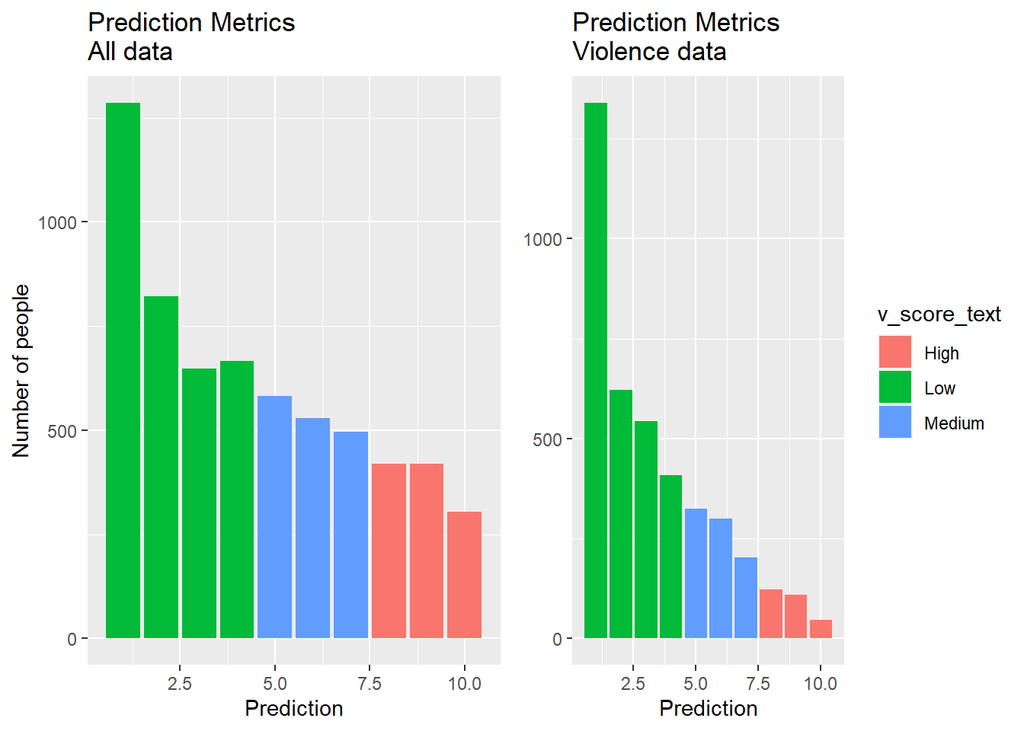

```r
#Propublica relevant vars: `glm(formula = score_factor ~ gender_factor + age_factor + race_factor + priors_count + crime_factor + two_year_recid, family = "binomial", data = df)`

ranking.all <- ggplot(recid.all, aes(x=decile_score, fill = score_text))+
  geom_bar(stat = "count", bin = 1) +
  ggtitle("Prediction Metrics\nAll data") +
  xlab("Prediction") +
  guides(fill = FALSE) +
  ylab("Number of people")

ranking.vio <- ggplot(recid.vio, aes(x=v_decile_score, fill = v_score_text))+
  geom_bar(stat = "count", bin = 1) +
  ggtitle("Prediction Metrics\nViolence data") +
  xlab("Prediction")+
  ylab(NULL)

grid.arrange(ranking.all, ranking.vio, ncol = 2)
```

# Demographics – example analysis with gender (can copy/paste for other)

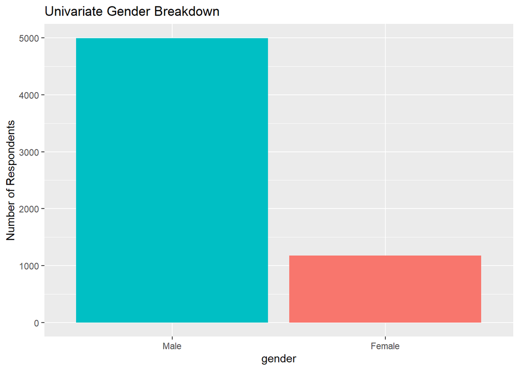

```r
#Propublica relevant vars: `glm(formula = score_factor ~ gender_factor + age_factor + race_factor + priors_count + crime_factor + two_year_recid, family = "binomial", data = df)`

### SEX ###

##############
# Univariate #
##############
gender_factor.uni.all <- ggplot(recid.all, aes(x=gender_factor, fill = sex))
gender_factor.uni.all +
  geom_bar(stat = "count", na.rm = F) +
  ggtitle("Univariate Gender Breakdown") +
  guides(fill = FALSE) +
  xlab("gender") +
  ylab("Number of Respondents")
```

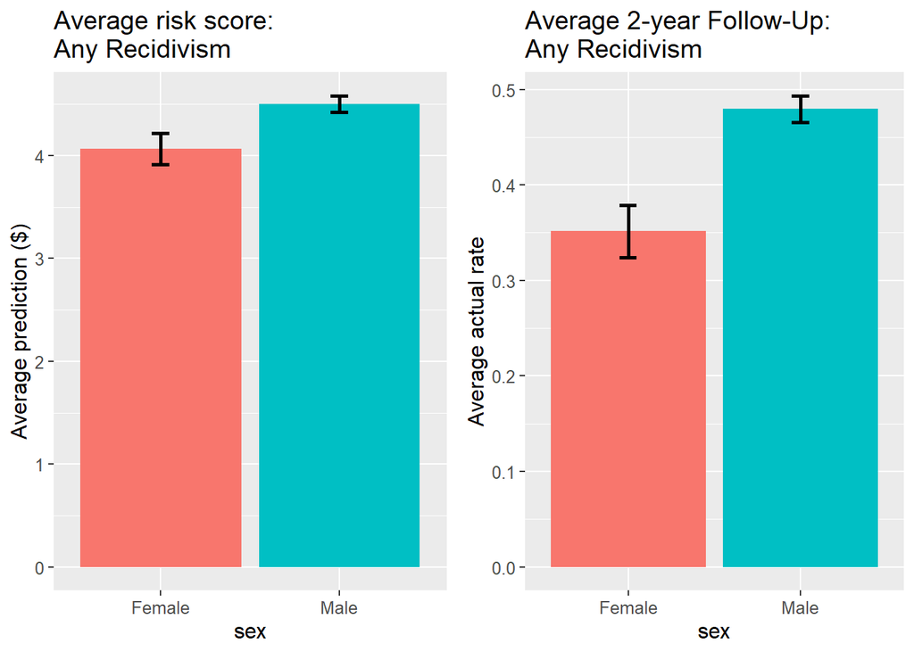

```r
#############################
# Bivariate w/ decile score #
#############################
#All
sex.bi.conf.all <- recid.all %>%
  group_by(sex) %>%
  summarize(Avgdecile_score = mean(decile_score),
            upper = t.test(decile_score)$conf.int[1],
            lower = t.test(decile_score)$conf.int[2])

sex.bi.all.dec <- ggplot(data = sex.bi.conf.all, aes(x = sex, y = Avgdecile_score,fill = sex)) +
  geom_bar(stat = "identity") +
  xlab("sex") +
  ylab("Average prediction ($)") +
  ggtitle("Average risk score: \nAny Recidivism") +
  guides(fill = FALSE) +
  geom_errorbar(aes(ymax = upper, ymin = lower), width = 0.1, size = 1) +
  theme(text = element_text(size=12))

#Violent
sex.bi.conf.vio <- recid.vio %>%
  group_by(sex) %>%
  summarize(Avgdecile_score = mean(decile_score),
            upper = t.test(v_decile_score)$conf.int[1],
            lower = t.test(v_decile_score)$conf.int[2])

sex.bi.vio.dec <- ggplot(data = sex.bi.conf.vio, aes(x = sex, y = Avgdecile_score,fill = sex)) +
  geom_bar(stat = "identity") +
  xlab("sex") +
  ylab("Average prediction ($)") +
  ggtitle("Average risk score: \nViolent Recidivism") +
  guides(fill = FALSE) +
  geom_errorbar(aes(ymax = upper, ymin = lower), width = 0.1, size = 1) +
  theme(text = element_text(size=12))

######################
# Bivariate w/ recid #
######################
#All
sex.bi.conf.all <- recid.all %>%
  group_by(sex) %>%
  summarize(Avgtwo_year_recid = mean(two_year_recid),
            upper = t.test(two_year_recid)$conf.int[1],
            lower = t.test(two_year_recid)$conf.int[2])

sex.bi.all.recid <- ggplot(data = sex.bi.conf.all, aes(x = sex, y = Avgtwo_year_recid,fill = sex)) +
  geom_bar(stat = "identity") +
  xlab("sex") +
  ylab("Average actual rate") +
  ggtitle("Average 2-year Follow-Up: \nAny Recidivism") +
  guides(fill = FALSE) +
  geom_errorbar(aes(ymax = upper, ymin = lower), width = 0.1, size = 1) +
  theme(text = element_text(size=12))

#Violent
sex.bi.conf.vio <- recid.vio %>%
  group_by(sex) %>%
  summarize(Avgtwo_year_recid = mean(two_year_recid),
            upper = t.test(two_year_recid)$conf.int[1],
            lower = t.test(two_year_recid)$conf.int[2])

sex.bi.vio.recid <- ggplot(data = sex.bi.conf.vio, aes(x = sex, y = Avgtwo_year_recid,fill = sex)) +
  geom_bar(stat = "identity") +
  xlab("sex") +
  ylab("Average actual rate") +
  ggtitle("Average 2-year Follow-Up: \nViolent Recidivism") +
  guides(fill = FALSE) +
  geom_errorbar(aes(ymax = upper, ymin = lower), width = 0.1, size = 1) +
  theme(text = element_text(size=12))

grid.arrange(sex.bi.all.dec, sex.bi.all.recid, ncol = 2)
```

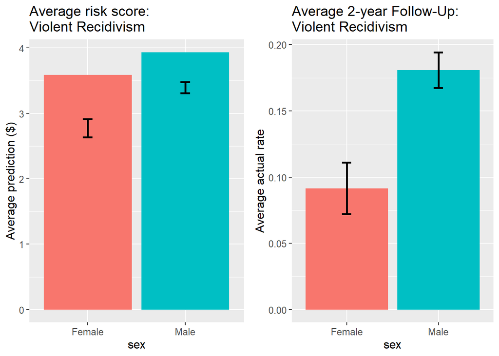

```r
grid.arrange(sex.bi.vio.dec, sex.bi.vio.recid, ncol = 2)
```